# Jingda-hw2

#### 1. Load the dataset.

```python
import pandas as pd
import random
random_seed = 2454
random.seed(random_seed)

creditcard_g10 = pd.read_csv('creditcard.csv')
```

#### 2. Show first 6 data points using head().

```python
#display first six points
creditcard_g10.head(6)
```

|  | Time | V1 | V2 | V3 | V4 | V5 | V6 | V7 | V8 | V9 | ... | V21 | V22 | V23 | V24 | V25 | V26 | V27 | V28 | Amount | Class |
| --- | --- | --- | --- | --- | --- | --- | --- | --- | --- | --- | --- | --- | --- | --- | --- | --- | --- | --- | --- | --- | --- |
| 0 | 0.0 | -1.359807 | -0.072781 | 2.536347 | 1.378155 | -0.338321 | 0.462388 | 0.239599 | 0.098698 | 0.363787 | ... | -0.018307 | 0.277838 | -0.110474 | 0.066928 | 0.128539 | -0.189115 | 0.133558 | -0.021053 | 149.62 | 0 |
| 1 | 0.0 | 1.191857 | 0.266151 | 0.166480 | 0.448154 | 0.060018 | -0.082361 | -0.078803 | 0.085102 | -0.255425 | ... | -0.225775 | -0.638672 | 0.101288 | -0.339846 | 0.167170 | 0.125895 | -0.008983 | 0.014724 | 2.69 | 0 |
| 2 | 1.0 | -1.358354 | -1.340163 | 1.773209 | 0.379780 | -0.503198 | 1.800499 | 0.791461 | 0.247676 | -1.514654 | ... | 0.247998 | 0.771679 | 0.909412 | -0.689281 | -0.327642 | -0.139097 | -0.055353 | -0.059752 | 378.66 | 0 |
| 3 | 1.0 | -0.966272 | -0.185226 | 1.792993 | -0.863291 | -0.010309 | 1.247203 | 0.237609 | 0.377436 | -1.387024 | ... | -0.108300 | 0.005274 | -0.190321 | -1.175575 | 0.647376 | -0.221929 | 0.062723 | 0.061458 | 123.50 | 0 |
| 4 | 2.0 | -1.158233 | 0.877737 | 1.548718 | 0.403034 | -0.407193 | 0.095921 | 0.592941 | -0.270533 | 0.817739 | ... | -0.009431 | 0.798278 | -0.137458 | 0.141267 | -0.206010 | 0.502292 | 0.219422 | 0.215153 | 69.99 | 0 |
| 5 | 2.0 | -0.425966 | 0.960523 | 1.141109 | -0.168252 | 0.420987 | -0.029728 | 0.476201 | 0.260314 | -0.568671 | ... | -0.208254 | -0.559825 | -0.026398 | -0.371427 | -0.232794 | 0.105915 | 0.253844 | 0.081080 | 3.67 | 0 |

6 rows × 31 columns

```python
#find unique values in class
creditcard_g10['Class'].unique()
```

```
array([0, 1])
```

#### 3. Describe pandas Dataframe by using describe.

```python
#escribe pandas Dataframe by using describe.
creditcard_g10.describe()
#from tabel below, we can see some basic info about the data, such as mean, std, min, max, etc.
```

|  | Time | V1 | V2 | V3 | V4 | V5 | V6 | V7 | V8 | V9 | ... | V21 | V22 | V23 | V24 | V25 | V26 | V27 | V28 | Amount | Class |
| --- | --- | --- | --- | --- | --- | --- | --- | --- | --- | --- | --- | --- | --- | --- | --- | --- | --- | --- | --- | --- | --- |
| count | 284807.000000 | 2.848070e+05 | 2.848070e+05 | 2.848070e+05 | 2.848070e+05 | 2.848070e+05 | 2.848070e+05 | 2.848070e+05 | 2.848070e+05 | 2.848070e+05 | ... | 2.848070e+05 | 2.848070e+05 | 2.848070e+05 | 2.848070e+05 | 2.848070e+05 | 2.848070e+05 | 2.848070e+05 | 2.848070e+05 | 284807.000000 | 284807.000000 |
| mean | 94813.859575 | 1.168375e-15 | 3.416908e-16 | -1.379537e-15 | 2.074095e-15 | 9.604066e-16 | 1.487313e-15 | -5.556467e-16 | 1.213481e-16 | -2.406331e-15 | ... | 1.654067e-16 | -3.568593e-16 | 2.578648e-16 | 4.473266e-15 | 5.340915e-16 | 1.683437e-15 | -3.660091e-16 | -1.227390e-16 | 88.349619 | 0.001727 |
| std | 47488.145955 | 1.958696e+00 | 1.651309e+00 | 1.516255e+00 | 1.415869e+00 | 1.380247e+00 | 1.332271e+00 | 1.237094e+00 | 1.194353e+00 | 1.098632e+00 | ... | 7.345240e-01 | 7.257016e-01 | 6.244603e-01 | 6.056471e-01 | 5.212781e-01 | 4.822270e-01 | 4.036325e-01 | 3.300833e-01 | 250.120109 | 0.041527 |
| min | 0.000000 | -5.640751e+01 | -7.271573e+01 | -4.832559e+01 | -5.683171e+00 | -1.137433e+02 | -2.616051e+01 | -4.355724e+01 | -7.321672e+01 | -1.343407e+01 | ... | -3.483038e+01 | -1.093314e+01 | -4.480774e+01 | -2.836627e+00 | -1.029540e+01 | -2.604551e+00 | -2.256568e+01 | -1.543008e+01 | 0.000000 | 0.000000 |
| 25% | 54201.500000 | -9.203734e-01 | -5.985499e-01 | -8.903648e-01 | -8.486401e-01 | -6.915971e-01 | -7.682956e-01 | -5.540759e-01 | -2.086297e-01 | -6.430976e-01 | ... | -2.283949e-01 | -5.423504e-01 | -1.618463e-01 | -3.545861e-01 | -3.171451e-01 | -3.269839e-01 | -7.083953e-02 | -5.295979e-02 | 5.600000 | 0.000000 |
| 50% | 84692.000000 | 1.810880e-02 | 6.548556e-02 | 1.798463e-01 | -1.984653e-02 | -5.433583e-02 | -2.741871e-01 | 4.010308e-02 | 2.235804e-02 | -5.142873e-02 | ... | -2.945017e-02 | 6.781943e-03 | -1.119293e-02 | 4.097606e-02 | 1.659350e-02 | -5.213911e-02 | 1.342146e-03 | 1.124383e-02 | 22.000000 | 0.000000 |
| 75% | 139320.500000 | 1.315642e+00 | 8.037239e-01 | 1.027196e+00 | 7.433413e-01 | 6.119264e-01 | 3.985649e-01 | 5.704361e-01 | 3.273459e-01 | 5.971390e-01 | ... | 1.863772e-01 | 5.285536e-01 | 1.476421e-01 | 4.395266e-01 | 3.507156e-01 | 2.409522e-01 | 9.104512e-02 | 7.827995e-02 | 77.165000 | 0.000000 |
| max | 172792.000000 | 2.454930e+00 | 2.205773e+01 | 9.382558e+00 | 1.687534e+01 | 3.480167e+01 | 7.330163e+01 | 1.205895e+02 | 2.000721e+01 | 1.559499e+01 | ... | 2.720284e+01 | 1.050309e+01 | 2.252841e+01 | 4.584549e+00 | 7.519589e+00 | 3.517346e+00 | 3.161220e+01 | 3.384781e+01 | 25691.160000 | 1.000000 |

8 rows × 31 columns

#### 4. Show correlation heat plot of the entire dataset using matplotlib and sns, choose any color pallet (except blue) you like (experiment).

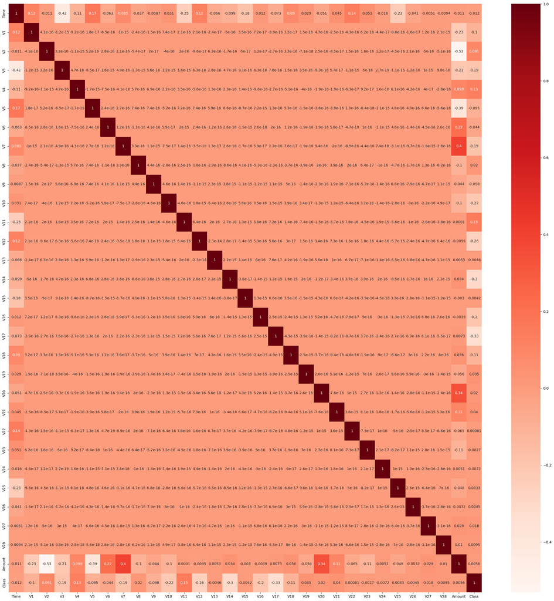

```python
#show correlation heat plot of the entire dataset using matplotlib and sns
import matplotlib.pyplot as plt
import seaborn as sns
plt.figure(figsize=(30,30))
cor_g10 = creditcard_g10.corr()
sns.heatmap(cor_g10, annot=True, cmap=plt.cm.Reds)
plt.show()
#this is the correlation heat plot of the entire dataset, and we can see the correlation between each feature and the class.
```

#### 5. Show the Scatterplot matrix for the dataframe, and export it.

```python
# I can not use all data to plot the scatter matrix becasue my kernel will die. So I just use "Time" "V1", "V2", "V3","Amount"
import plotly.express as px
fig_g10 = px.scatter_matrix(
    creditcard_g10,
    dimensions=["Time","V1", "V2", "V3", "Amount"],
    color="Class",
    title="Scatter Matrix Plot",
    opacity=0.5,
    hover_name="Class",
    height=600,
    width=800,

)

fig_g10.update_traces(marker=dict(size=5))

fig_g10.show()
#this is the scatter matrix plot of the five columns of entire dataset, and we can see the correlation between each feature and the class.
```

[output not shown]

```python
fig_g10.write_html("scatter-matrix.html")
#export the scatter matrix plot to html file.
# The plot does now show up after I generated a html file. I add the file to git repo in case you want to check it.
```

#### 6. Split the dataset into the Training set and Test set. Choose your preferred split and justify the rationale.

```python
from sklearn.model_selection import train_test_split

X_g10 = creditcard_g10.drop("Class", axis=1)
y_g10 = creditcard_g10["Class"]

#split the data into a 70% training set and a 30% test set.
# Because the data is imbalanced, we must make sure that the training and test sets have the appropriate proportion of fraudulent transaction。
X_train_g10, X_test_g10, y_train_g10, y_test_g10 = train_test_split(X_g10, y_g10, test_size=0.3, random_state=random_seed)

print("X_train shape:", X_train_g10.shape)
print("X_test shape:", X_test_g10.shape)
print("y_train shape:", y_train_g10.shape)
print("y_test shape:", y_test_g10.shape)
```

```
X_train shape: (199364, 30)
X_test shape: (85443, 30)
y_train shape: (199364,)
y_test shape: (85443,)
```

```python
#find how many 1 in y_train and y_test and y so that we can know if the proportion of fraudulent transaction is appropriate.
#the label is highly imbalanced.
print("y_train 1:", y_train_g10.sum())
print("y_test 1:", y_test_g10.sum())
print("y 1:", y_g10.sum())
```

```
y_train 1: 343
y_test 1: 149
y 1: 492
```

#### 7. Perform classification and compare the results.

```python
import numpy as np
import pandas as pd
import matplotlib.pyplot as plt
import seaborn as sns
from sklearn.metrics import accuracy_score
from sklearn.model_selection import cross_val_score, StratifiedKFold
from sklearn.linear_model import LogisticRegression
from sklearn.neighbors import KNeighborsClassifier
from sklearn.tree import DecisionTreeClassifier
from sklearn.svm import SVC
from sklearn.naive_bayes import GaussianNB
from sklearn.ensemble import RandomForestClassifier, BaggingClassifier, GradientBoostingClassifier
import xgboost as xgb

# Setting random seed for reproducibility
random_seed = 2454
np.random.seed(random_seed)

#all alassfiers that we should use
classifiers_g10 = [
    LogisticRegression(max_iter=1000),
    KNeighborsClassifier(),
    DecisionTreeClassifier(),
    SVC(probability=True),
    GaussianNB(),
    RandomForestClassifier(),
    BaggingClassifier(),
    GradientBoostingClassifier(),
    xgb.XGBClassifier(eval_metric='logloss')
]

#cross validation with 5 folds
cv_g10 = StratifiedKFold(n_splits=5, shuffle=True, random_state=random_seed)

def evaluate_models_with_cv(models, X_train, y_train, cv):
    model_scores = {}

    for model in models:
        model_name = model.__class__.__name__
        scores = cross_val_score(model, X_train, y_train, cv=cv_g10, scoring='accuracy')
        model_scores[model_name] = scores
        print("{} average CV accuracy: {:.4f}".format(model_name, np.mean(scores)))

    return model_scores

#get the accuracy scores for each model after cv
model_scores_g10 = evaluate_models_with_cv(classifiers_g10, X_train_g10, y_train_g10, cv_g10)
# I only choose one metric to evaluate the model, so I only use accuracy score.
```

```
LogisticRegression average CV accuracy: 0.9991
KNeighborsClassifier average CV accuracy: 0.9983
DecisionTreeClassifier average CV accuracy: 0.9991
SVC average CV accuracy: 0.9983
GaussianNB average CV accuracy: 0.9925
RandomForestClassifier average CV accuracy: 0.9995
BaggingClassifier average CV accuracy: 0.9995
GradientBoostingClassifier average CV accuracy: 0.9990
XGBClassifier average CV accuracy: 0.9996
```

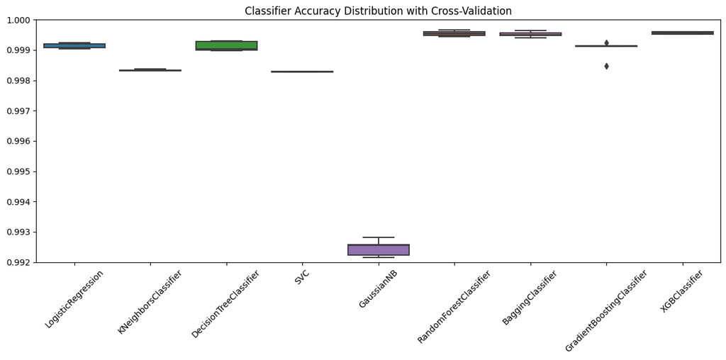

```python
# The box plots generated by Plotly do not show up after I generated the html, so I use seaborn to plot the boxplot.
def plot_model_scores_mpl(model_scores):
    df = pd.DataFrame(model_scores)

    plt.figure(figsize=(12,6))

    #create the boxplot using Seaborn
    sns.boxplot(data=df)

    #set title, y-axis range, and rotate x-axis labels
    plt.title('Classifier Accuracy Distribution with Cross-Validation')
    # because the accuracy of the model is very high, I set the y-axis range from 0.992 to 1.0
    plt.ylim(0.992, 1.0)
    plt.xticks(rotation=45)


    plt.tight_layout()
    plt.show()

#show the plot
plot_model_scores_mpl(model_scores_g10)
```

The RandomForestClassifier, BaggingClassifier, and XGBClassifier show the highest cross-validation accuracies, all above 0.9995. GaussianNB has the lowest accuracy at 0.9925. Other models like LogisticRegression, DecisionTreeClassifier, and GradientBoostingClassifier perform closely, around 0.9991.